# Text group: Beauty reccomendation system

1. Introduction
   1. Setting up the environment
   2. Creating full product description column
2. Data Pre-processing
3. Preparing the Data for NLP Analysis
   1. Removing Stopwords
   2. Lemmatization and Punctuation Removal
   3. Obtaining our DFMs
4. Exploratory Data Analysis
   1. Data distribution
   2. Word Clouds for Product vs Review Data
   3. Building a rating prediction model from review data
5. Calculating Positivity Score on the Review Data
6. Topic Modeling
   1. Based on Product Descriptions
      1. Visualising Topic modelling results
   2. Based on Reviews
   3. Comparing Topics on Subreddit Skincare Addicts
      1. Analysis of the r/SkincareAddicts Topics
7. Finding the Closest Product Based on Vector Similarity to Reviews

# Introduction

Amazon review data provides access to a wealth of textual information related to consumer interests and opinions. In addition to collecting brand liking metrics from customers based on their product ratings, we believe it is possible to build a recommendation system specifically for skincare products (but potentially applicable to other sectors as well) by clustering products based on skin concerns and overall consumer sentiment.

## Setting up the environment

```python
# Downloading and loading resources
import spacy
from spacy.lang.en.examples import sentences
spacy_model = spacy.load('en_core_web_md')
from nltk.stem.snowball import SnowballStemmer
snow_stemmer = SnowballStemmer(language='english')

# General purpose packages
import os
import warnings
import json
from IPython.display import Image, display

# Data manipulation and analysis
import pandas as pd
import numpy as np
from scipy import stats, sparse

# Text processing and natural language processing
import re
import string
import nltk
from nltk.tokenize import word_tokenize
from nltk.stem import WordNetLemmatizer
from nltk.corpus import stopwords
from textblob import TextBlob
from vaderSentiment.vaderSentiment import SentimentIntensityAnalyzer
from tqdm import tqdm

# Machine learning and feature extraction
from sklearn.feature_extraction.text import CountVectorizer, TfidfVectorizer
from sklearn.model_selection import train_test_split, ShuffleSplit
from sklearn.linear_model import Lasso
from sklearn.decomposition import NMF

# Visualization
import matplotlib.pyplot as plt
import seaborn as sns
from adjustText import adjust_text
from wordcloud import WordCloud
import pyLDAvis
import pyLDAvis.lda_model
import matplotlib.font_manager as fm


#for the network vis
import networkx as nx
from pyvis.network import Network

# Statistical modeling
import statsmodels.api as sm

# Miscellaneous
from itertools import islice
nltk.download('punkt')
# Warning configuration
warnings.filterwarnings("ignore")
```

```python
nltk.download('punkt')
nltk.download('wordnet')
nltk.download('punkt')
nltk.download('stopwords')
```

```
True
```

```python
# Open the other Jupyter notebook with functions from class (e.g., Tab dfm)
%run functions_for_project.ipynb
```

# Data Pre-processing

```python
data = pd.read_json('/Users/behemoth/Downloads/Text assignrment group/merged_df_3_filtered.json', lines=True)
data.head()
```

|  | main_category | title_x | average_rating | rating_number | features | description | price | images_x | videos | store | ... | rating | title_y | text | images_y | asin | user_id | timestamp | helpful_vote | verified_purchase | word_count |
| --- | --- | --- | --- | --- | --- | --- | --- | --- | --- | --- | --- | --- | --- | --- | --- | --- | --- | --- | --- | --- | --- |
| 0 | Health & Personal Care | Babo Botanicals Sheer Zinc Continuous Spray Su... | 4.3 | 4526 | [100% GOOD FOR YOU & YOUR FAMILY: A fast-absor... | [Get the comfort of a lotion sunscreen and the... | 18.99 | [{'thumb': 'https://m.media-amazon.com/images/... | [{'title': 'Be Aware! Very Watery, Do Not Reco... | Babo Botanicals | ... | 5 | Great convenient nontoxic spray sunblock optio... | I am very serious about nontoxic products for ... | [] | B01ALT5MKW | AFEAKGEFGNXV4W27BCVZIMLBGBCQ | 2018-11-12 17:26:31.203 | 5 | True | 305 |
| 1 | Health & Personal Care | Babo Botanicals Sheer Zinc Continuous Spray Su... | 4.3 | 4526 | [100% GOOD FOR YOU & YOUR FAMILY: A fast-absor... | [Get the comfort of a lotion sunscreen and the... | 18.99 | [{'thumb': 'https://m.media-amazon.com/images/... | [{'title': 'Be Aware! Very Watery, Do Not Reco... | Babo Botanicals | ... | 5 | My favorite sunscreen | I love this sunscreen and have been carrying a... | [] | B01ALT5MKW | AHUDCX6EMEC4FLRCLTAHQBVXZ3XA | 2019-08-05 14:29:19.193 | 36 | True | 263 |
| 2 | Health & Personal Care | Babo Botanicals Sheer Zinc Continuous Spray Su... | 4.3 | 4526 | [100% GOOD FOR YOU & YOUR FAMILY: A fast-absor... | [Get the comfort of a lotion sunscreen and the... | 18.99 | [{'thumb': 'https://m.media-amazon.com/images/... | [{'title': 'Be Aware! Very Watery, Do Not Reco... | Babo Botanicals | ... | 2 | Best mineral sunscreen to apply, but I got bur... | We are a family of boaters and also spend a lo... | [] | B01ALT5MKW | AESIW57B375ELLGEBEYSNIWXQUUA | 2016-05-14 23:08:25.000 | 20 | True | 238 |
| 3 | Health & Personal Care | Babo Botanicals Sheer Zinc Continuous Spray Su... | 4.3 | 4526 | [100% GOOD FOR YOU & YOUR FAMILY: A fast-absor... | [Get the comfort of a lotion sunscreen and the... | 18.99 | [{'thumb': 'https://m.media-amazon.com/images/... | [{'title': 'Be Aware! Very Watery, Do Not Reco... | Babo Botanicals | ... | 3 | We still burned. | On paper, this sunscreen is it. Natural ingred... | [] | B01ALT5MKW | AELPEPVFIGID7UOMCM6UWTFM5JDQ | 2021-06-18 15:02:22.272 | 0 | True | 329 |
| 4 | Health & Personal Care | Babo Botanicals Sheer Zinc Continuous Spray Su... | 4.3 | 4526 | [100% GOOD FOR YOU & YOUR FAMILY: A fast-absor... | [Get the comfort of a lotion sunscreen and the... | 18.99 | [{'thumb': 'https://m.media-amazon.com/images/... | [{'title': 'Be Aware! Very Watery, Do Not Reco... | Babo Botanicals | ... | 2 | Chalky white & paste like | I bought this product to go away on a month-lo... | [{'small_image_url': 'https://m.media-amazon.c... | B01ALT5MKW | AEAAJTZ463VX22ZQCBUQT7EHZJSA | 2023-03-12 03:58:12.282 | 2 | True | 171 |

5 rows × 26 columns

Renaming columns after the merge for simplicity as some now have the same name or could be confused with something else.

```python
mergeddf = data.rename(columns={'title_x': 'product title', 'images_x': 'product image', 'images_y': 'review images', 'title_y': 'review title', 'text' :'review_text' })
```

```python
mergeddf.columns
```

```
Index(['main_category', 'product title', 'average_rating', 'rating_number',
       'features', 'description', 'price', 'product image', 'videos', 'store',
       'categories', 'details', 'parent_asin', 'bought_together', 'subtitle',
       'author', 'rating', 'review title', 'review_text', 'review images',
       'asin', 'user_id', 'timestamp', 'helpful_vote', 'verified_purchase',
       'word_count'],
      dtype='object')
```

```python
mergeddf['description'] = mergeddf['description'].apply(lambda x: ' '.join(x) if isinstance(x, list) else x)
mergeddf['features'] = mergeddf['features'].apply(lambda x: ' '.join(x) if isinstance(x, list) else x)
```

dropping empty columns

```python
print(data['subtitle'].unique())
mergeddf.drop(columns=['subtitle'], inplace=True)
```

```
[nan]
```

```python
reviews_df = mergeddf[['author', 'rating', 'review title', 'review_text', 'review images', 'asin', 'user_id', 'timestamp', 'helpful_vote', 'verified_purchase', 'word_count', 'parent_asin']]
product_df = mergeddf.drop(columns=['author', 'rating', 'review title', 'review_text', 'review images', 'asin', 'user_id', 'timestamp', 'helpful_vote', 'verified_purchase', 'word_count'])
product_df.drop_duplicates(subset=['parent_asin'], inplace=True)
print("Product DataFrame Shape:", product_df.shape)
print("Reviews DataFrame Shape:", reviews_df.shape)
reviews_df['review_text'].str.lower()
product_df['description'].str.lower()
```

```
Product DataFrame Shape: (14101, 14)
Reviews DataFrame Shape: (86614, 12)
```

```
0        get the comfort of a lotion sunscreen and the ...
19       designed to protect baby-soft skin, blue lizar...
20       sun protected skin is healthy skin, and a safe...
25       open the jar and instantly escape to the warm ...
28       product description help give your skin superi...
                               ...
86609
86610    my beauty diary provides a wide selection of m...
86611
86612
86613    garnier fructis full & plush mega full thicken...
Name: description, Length: 14101, dtype: object
```

Four analysis as some products are lacking the description, but do contain product feature and product title we decided to create one single full product description column with all the elements of product description.

```python
product_df['product title'].head()
```

```
0     Babo Botanicals Sheer Zinc Continuous Spray Su...
19    BLUE LIZARD Australian Sunscreen Blue Lizard S...
20    Jergens Natural Glow Face Fair to Medium with ...
25    Florida Salt Scrubs Hand & Body Scrub (Key Lim...
28    Neutrogena Beach Defense Water-Resistant Sunsc...
Name: product title, dtype: object
```

```python
product_df['features']
```

```
0        100% GOOD FOR YOU & YOUR FAMILY: A fast-absorb...
19       We love the reef - to help protect delicate co...
20       FLAWLESS SELF TANNING: Create a flawless tan f...
25       For use on: your body, feet and hands. 100% al...
28       6.7-fluid ounce bottle of Neutrogena Beach Def...
                               ...
86609    Josie Maran Whipped Argan Oil Face Butter Ultr...
86610    Provides a fresh whiteness Brightens and relax...
86611    Comprehensive anti-aging skincare kit includes...
86612    Customizable Sunless Tanning: Mix our self-tan...
86613                             24H Thicker, Fuller Body
Name: features, Length: 14101, dtype: object
```

```python
product_df['description'].replace(np.nan, '', regex=True)
product_df['full description'] = product_df['product title'] + ' ' + product_df['features'] + ' ' + product_df['description']
print(product_df['full description'].isnull().sum())
```

```
0
```

# Preparing the Data for NLP Analysis

## Removing Stopwords

The first step in preparing the data for NLP analysis is to remove stopwords using the spaCy library.

```python
nlp = spacy.load('en_core_web_sm')

def remove_stopwords(text):
    if isinstance(text, str):
        doc = nlp(text)
        filtered_tokens = [token.text for token in doc if not token.is_stop]
        filtered_text = ' '.join(filtered_tokens)
        return filtered_text
    else:
        return ''

tqdm.pandas()
product_df['nostopwords_description'] = product_df['full description'].progress_apply(remove_stopwords)
```

```python
tqdm.pandas()
reviews_df['nostopwords_review_text'] = reviews_df['review_text'].progress_apply(remove_stopwords)
```

## Lemmatization and Punctuation Removal

After removing stopwords, the product descriptions and reviews are lemmatized to keep the simplest form of each word. Punctuation is also removed during this process.

```python
stop_words = set(spacy.lang.en.stop_words.STOP_WORDS)

def preprocess_text(text):
    # Remove punctuations
    text = text.translate(str.maketrans('', '', string.punctuation)) if text else ''
    text = text.replace('br', '') if text else ''

    # Remove numbers
    text = ''.join(char for char in text if not char.isdigit()) if text else ''

    # Process the text using spaCy
    doc = nlp(text) if text else ''

    # Lemmatize tokens and remove stop words
    lemmatized_tokens = [token.lemma_ for token in doc if not token.is_stop] if doc else []

    # Join the lemmatized tokens back into text
    lemmatized_text = ' '.join(lemmatized_tokens) if lemmatized_tokens else ''

    return lemmatized_text

tqdm.pandas()
product_df['lemmatized_description'] = product_df['nostopwords_description'].progress_apply(preprocess_text)
```

```python
product_df.to_csv('product.csv')
product_df['lemmatized_description'].head()
```

```
0     Babo Botanicals Sheer Zinc Continuous Spray Su...
19    BLUE lizard australian Sunscreen Blue Lizard S...
20    Jergens Natural Glow Face Fair Medium Jergens ...
25    Florida Salt Scrubs Hand   Body Scrub   Key Li...
28    Neutrogena Beach Defense Water   resistant Sun...
Name: lemmatized_description, dtype: object
```

```python
#reviews_df['lemmatized_review_text'] = reviews_df['nostopwords_review_text'].progress_apply(preprocess_text)
```

```python
#reviews_df.to_csv('reviews.csv')
#reviews_df['lemmatized_review_text'].head()
```

```python
#loading from csv output for simplicity
reviews_df = pd.read_csv('reviews.csv')
product_df = pd.read_csv('product.csv')
```

## Obtaining our DFMs

Now that we have lemmatised our review and description text we can on this column run the TAB dfm function which will tokenise the review text and remove stop words and return us a document feature matrix.

```python
product_tdm, product_mtx = TAB_dfm(product_df['lemmatized_description'], ngrams_range=(1, 3))
```

```python
review_tdm, review_mtx = TAB_dfm(reviews_df['lemmatized_review_text'], ngrams_range=(1, 3))
```

# Exploratory Data Analysis

In this section we take a look at our data, what type of words are more common, what kind of prediction model can we build. In preparation for Topic modelling.

## Data distribution

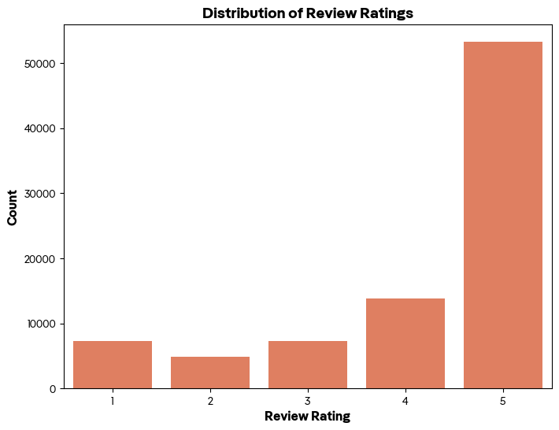

```python
import matplotlib.pyplot as plt
import seaborn as sns
from matplotlib import font_manager

# normal font
font_path = "Pangea-Regular.otf"
font_prop = font_manager.FontProperties(fname=font_path)

#bold font
font_path_2 = "Pangea-Bold.otf"
font_bold = font_manager.FontProperties(fname=font_path_2)

plt.figure(figsize=(8, 6))
sns.countplot(x='rating', data=reviews_df, color='#F4744C')

plt.xlabel('Review Rating', fontproperties=font_bold, fontsize=12)
plt.ylabel('Count', fontproperties=font_bold, fontsize=12)
plt.title('Distribution of Review Ratings', fontproperties=font_bold, fontsize=14)

# Set the font for the x-tick labels
plt.xticks(fontproperties=font_prop, fontsize=10)

# Set the font for the y-tick labels
plt.yticks(fontproperties=font_prop, fontsize=10)

plt.savefig('distribution_review_ratings.svg', format='svg', dpi=300, bbox_inches='tight')

plt.show()
```

```python
distribution_df = mergeddf.drop_duplicates(subset=['parent_asin']).set_index('parent_asin')['rating_number']
```

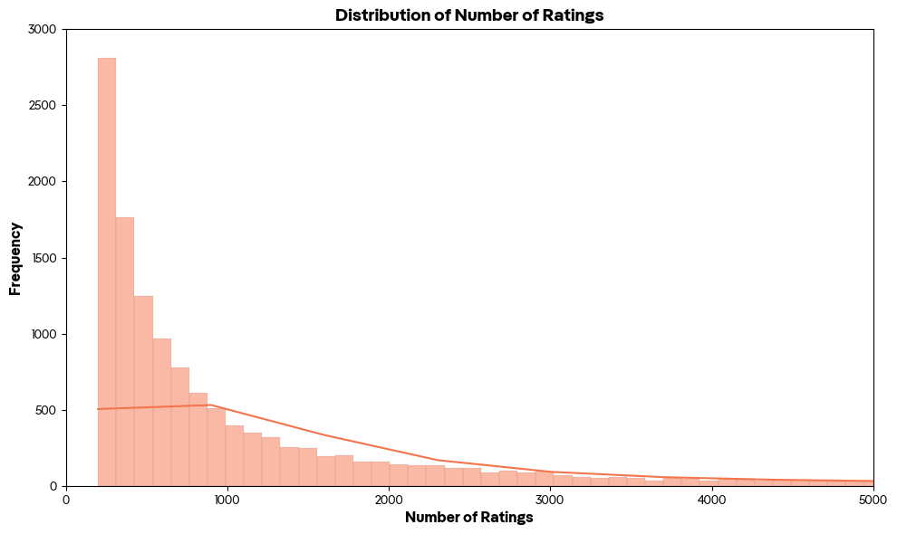

```python
plt.figure(figsize=(10, 6))
sns.histplot(distribution_df, kde=True, color='#F4744C')

plt.xlabel('Number of Ratings', fontproperties=font_bold, fontsize=12)
plt.ylabel('Frequency', fontproperties=font_bold, fontsize=12)
plt.title('Distribution of Number of Ratings', fontproperties=font_bold, fontsize=14)

# Set the font for the x-tick labels
plt.xticks(fontproperties=font_prop, fontsize=10)

# Set the font for the y-tick labels
plt.yticks(fontproperties=font_prop, fontsize=10)

plt.xlim(0, 5000)
plt.ylim(0, 3000)

# Customize the plot style
sns.set_style("whitegrid")
plt.tight_layout()

plt.savefig('distribution_num_ratings.svg', format='svg', dpi=300, bbox_inches='tight')
plt.show()
```

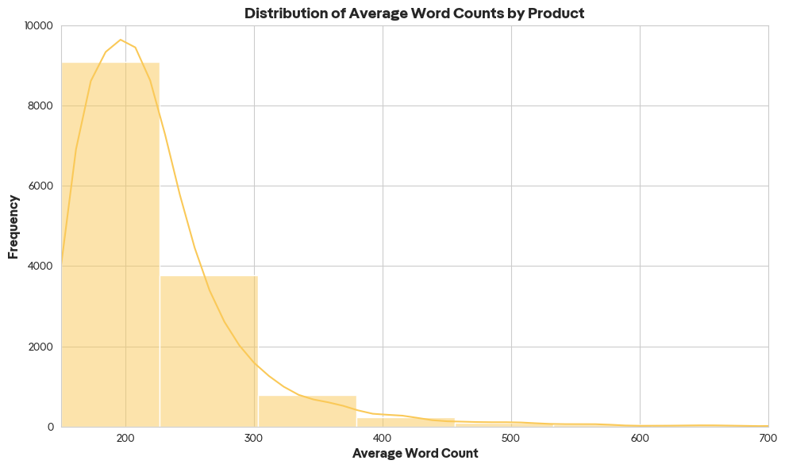

```python
avg_word_counts = reviews_df.groupby('parent_asin')['word_count'].mean().reset_index(name='avg_word_count')

plt.figure(figsize=(10, 6))
sns.histplot(data=avg_word_counts, x='avg_word_count', bins=30, kde=True, color='#FAC958')

plt.xlabel('Average Word Count', fontproperties=font_bold, fontsize=12)
plt.ylabel('Frequency', fontproperties=font_bold, fontsize=12)
plt.title('Distribution of Average Word Counts by Product', fontproperties=font_bold, fontsize=14)
plt.xticks(fontproperties=font_prop, fontsize=10)
plt.yticks(fontproperties=font_prop, fontsize=10)

plt.xlim(150, 700)
plt.ylim(0, 10000)

# Customize the plot style
sns.set_style("whitegrid")
plt.tight_layout()

plt.savefig('distribution_avg_word_counts.svg', format='svg', dpi=300, bbox_inches='tight')
plt.show()
```

## Word Clouds for Product vs Review Data

Word clouds are generated to visualize the most common words in the product descriptions and reviews, providing insights into the key topics and themes discussed.

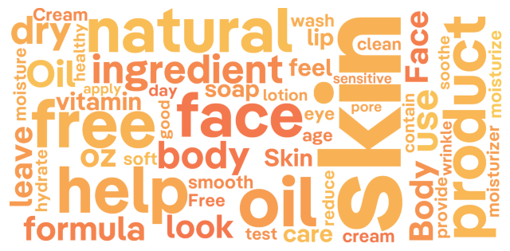

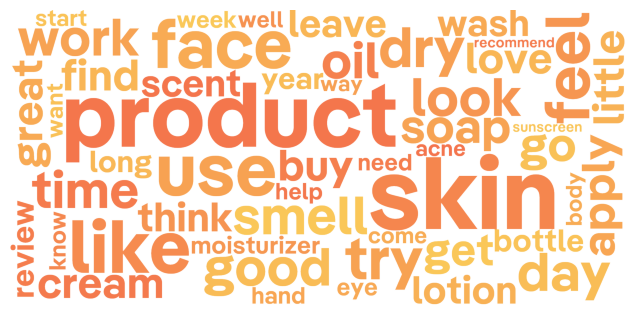

```python
import io
import base64
from matplotlib.colors import LinearSegmentedColormap

product_description = ' '.join(product_df['lemmatized_description'].dropna().tolist())
product_description_counter = Counter(product_description.split())
product_top_labels_50 = product_description_counter.most_common(50)

# For review_df
review_text = ' '.join(reviews_df['lemmatized_review_text'].dropna().tolist())
review_text_counter = Counter(review_text.split())
review_top_labels_50 = review_text_counter.most_common(50)


def generate_wordcloud(top_labels, font_path, output_file, colors):
    word_freq = dict(top_labels)
    cmap = LinearSegmentedColormap.from_list("custom", colors)

    fog_machine = WordCloud(width=2100, height=1000, min_font_size=14, background_color="rgba(255, 255, 255, 0)", mode="RGBA", colormap=cmap, font_path=font_path)
    fog_machine.generate_from_frequencies(word_freq)

    img = fog_machine.to_image()
    img.save(output_file, format='PNG')

    # Display the word cloud image
    plt.figure(figsize=(8, 6))
    plt.imshow(fog_machine, interpolation="bilinear")
    plt.axis("off")
    plt.show()

colors_product = ["#FAC958","#F4744C"]
# Generate and save word cloud for product_df as SVG
generate_wordcloud(product_top_labels_50, "Pangea-Bold.otf", "product_wordcloud.png", colors_product )
colors_review =  ["#FAC958","#F4744C"]
# Generate and save word cloud for review_df as SVG
generate_wordcloud(review_top_labels_50, "Pangea-Bold.otf", "review_wordcloud.png", colors_review)
```

## Building a rating prediction model from review data

This part is included in the R.html output in the zipped file. Below is only the processing of the sephora data.

```python
sephora_data = pd.read_csv('reviews_1250-end.csv')
```

```python
sephora_data['nostopwords_text'] = sephora_data['review_text'].progress_apply(remove_stopwords)
```

```python
sephora_data['lemmatized_text'] = sephora_data['nostopwords_text'].progress_apply(preprocess_text)
```

```python
sephora_data.to_csv('sephora_data.csv')
```

# Calculating positivity score on the review data

As part of our analysis we want to be able to use the sentiment score of the reviews to find out the average sentiment score of each product. We will be using the Vader sentiment package to run this analysis.

```python
analyzer = SentimentIntensityAnalyzer()

def get_sentiment_scores(text):
    sentiment = analyzer.polarity_scores(text)
    return sentiment['compound']

reviews_df['sentiment_score'] = reviews_df['lemmatized_review_text'].apply(get_sentiment_scores)
```

```python
def get_sentiment_label(score):
    if score >= 0.05:
        return 'Positive'
    elif score <= -0.05:
        return 'Negative'
    else:
        return 'Neutral'

reviews_df['sentiment_label'] = reviews_df['sentiment_score'].apply(get_sentiment_label)
```

Calculate the average sentiment score and sentiment label for each asin (unique product identificator) in reviews_df/

```python
reviews_summary = reviews_df.groupby('parent_asin')[['sentiment_score']].mean()
product_df = product_df.merge(reviews_summary, how='left', left_on='parent_asin', right_index=True)
print(product_df.shape)
```

```
(14101, 19)
```

```python
product_df['sentiment_label'] = product_df['sentiment_score'].apply(get_sentiment_label)
```

```python
product_df.to_csv('product_with_sentiment.csv')
product_df.head()
```

|  | Unnamed: 0 | main_category | product title | average_rating | rating_number | features | description | price | product image | videos | store | categories | details | parent_asin | bought_together | full description | nostopwords_description | lemmatized_description | sentiment_score | sentiment_label |
| --- | --- | --- | --- | --- | --- | --- | --- | --- | --- | --- | --- | --- | --- | --- | --- | --- | --- | --- | --- | --- |
| 0 | 0 | Health & Personal Care | Babo Botanicals Sheer Zinc Continuous Spray Su... | 4.3 | 4526 | 100% GOOD FOR YOU & YOUR FAMILY: A fast-absorb... | Get the comfort of a lotion sunscreen and the ... | 18.99 | [{'thumb': 'https://m.media-amazon.com/images/... | [{'title': 'Be Aware! Very Watery, Do Not Reco... | Babo Botanicals | ['Beauty & Personal Care', 'Skin Care', 'Sunsc... | {'Scent': 'Unscented', 'Product Benefits': 'Fa... | B01ALT5MKW | NaN | Babo Botanicals Sheer Zinc Continuous Spray Su... | Babo Botanicals Sheer Zinc Continuous Spray Su... | Babo Botanicals Sheer Zinc Continuous Spray Su... | 0.887532 | Positive |
| 1 | 19 | Health & Personal Care | BLUE LIZARD Australian Sunscreen Blue Lizard S... | 4.7 | 783 | We love the reef - to help protect delicate co... | Designed to protect baby-soft skin, Blue Lizar... | 27.80 | [{'thumb': 'https://m.media-amazon.com/images/... | [{'title': 'Blue Lizard Baby Sunscreen', 'url'... | BLUE LIZARD | ['Beauty & Personal Care', 'Skin Care', 'Sunsc... | {'Scent': 'Unscented', 'Sun Protection': '30+ ... | B01M67WKPZ | NaN | BLUE LIZARD Australian Sunscreen Blue Lizard S... | BLUE LIZARD Australian Sunscreen Blue Lizard S... | BLUE lizard australian Sunscreen Blue Lizard S... | 0.952200 | Positive |
| 2 | 20 | All Beauty | Jergens Natural Glow Face Fair to Medium with ... | 4.5 | 20144 | FLAWLESS SELF TANNING: Create a flawless tan f... | Sun protected skin is healthy skin, and a safe... | 20.46 | [{'thumb': 'https://m.media-amazon.com/images/... | [{'title': 'Jergens Natural Glow moisturizer R... | Jergens | ['Beauty & Personal Care', 'Skin Care', 'Body'... | {'Item Form': 'Lotion', 'Skin Type': 'All', 'M... | B09NXPFFQN | NaN | Jergens Natural Glow Face Fair to Medium with ... | Jergens Natural Glow Face Fair Medium Jergens ... | Jergens Natural Glow Face Fair Medium Jergens ... | 0.819400 | Positive |
| 3 | 25 | All Beauty | Florida Salt Scrubs Hand & Body Scrub (Key Lim... | 4.6 | 1343 | For use on: your body, feet and hands. 100% al... | Open the jar and instantly escape to the warm ... | 35.99 | [{'thumb': 'https://m.media-amazon.com/images/... | [{'title': 'How to use The Keys Salt Scrub, bo... | Florida Salt Scrubs | ['Beauty & Personal Care', 'Skin Care', 'Body'... | {'Brand': 'Florida Salt Scrubs', 'Skin Type': ... | B0BWDNQ3XR | NaN | Florida Salt Scrubs Hand & Body Scrub (Key Lim... | Florida Salt Scrubs Hand & Body Scrub ( Key Li... | Florida Salt Scrubs Hand Body Scrub Key Li... | 0.969033 | Positive |
| 4 | 28 | All Beauty | Neutrogena Beach Defense Water-Resistant Sunsc... | 4.7 | 2003 | 6.7-fluid ounce bottle of Neutrogena Beach Def... | Product Description Help give your skin superi... | 9.42 | [{'thumb': 'https://m.media-amazon.com/images/... | [{'title': 'How to Choose the Right Sunscreen ... | Neutrogena | ['Beauty & Personal Care', 'Skin Care', 'Sunsc... | {'Sun Protection': '30 SPF', 'Item Weight': '0... | B00AKG404Q | NaN | Neutrogena Beach Defense Water-Resistant Sunsc... | Neutrogena Beach Defense Water - Resistant Sun... | Neutrogena Beach Defense Water resistant Sun... | 0.904200 | Positive |

# Topic modelling

Below the function used to display the topics.

```python
def display_topics(model, feature_names, no_top_words, topic_names=None):
    for ix, topic in enumerate(model.components_):
        if not topic_names or not topic_names[ix]:
            print("\nTopic ", ix)
        else:
            print("\nTopic: '",topic_names[ix],"'")
        print(", ".join([feature_names[i]
                        for i in topic.argsort()[:-no_top_words - 1:-1]]))
```

## Based on the product descriptions

We decided to run a NMF matrix on the product description and reviews as well to compare. Below is the function to display the topics.

```python
#where x is the dfm matrix
x=product_tdm.values

nmf = NMF(n_components=20, solver="mu")
product_topic= nmf.fit_transform(x)   # score for each topic by product description
topic_word =pd.DataFrame(nmf.components_.round(3),
                        columns = product_tdm.columns)

print(topic_word)
display_topics(nmf, product_tdm.columns, 20)
```

```
     abil  absolut  absorb  absorb quick  absorb skin  absorpt  acceler  \
0   0.086    0.001   0.441         0.001        0.135    0.091    0.000
1   0.000    0.001   0.000         0.000        0.000    0.000    0.000
2   0.045    0.074   0.476         0.025        0.127    0.019    0.000
3   0.008    0.000   0.000         0.063        0.000    0.032    0.000
4   0.036    0.000   0.000         0.000        0.000    0.000    0.000
5   0.000    0.013   0.813         0.203        0.007    0.000    0.013
6   0.033    0.011   0.121         0.010        0.000    0.042    0.000
7   0.003    0.003   0.000         0.000        0.000    0.000    0.000
8   0.057    0.045   0.000         0.000        0.009    0.000    0.064
9   0.020    0.000   1.177         0.339        0.049    0.000    0.000
10  0.000    0.000   0.001         0.000        0.000    0.116    0.000
11  0.000    0.000   0.312         0.105        0.000    0.000    0.141
12  0.000    0.023   0.048         0.000        0.000    0.024    0.305
13  0.077    0.005   0.280         0.060        0.046    0.035    0.016
14  0.000    0.076   0.001         0.000        0.000    0.003    0.000
15  0.000    0.034   0.000         0.000        0.000    0.000    0.000
16  0.000    0.045   0.000         0.000        0.000    0.001    0.000
17  0.000    0.001   1.230         0.381        0.010    0.018    0.031
18  0.095    0.058   0.401         0.000        0.028    0.114    0.015
19  0.017    0.035   0.000         0.000        0.000    0.000    0.000

    achiev   acid  acid help  ...  young look  young look skin  youth  \
0    0.117  0.242      0.053  ...       0.074            0.062  0.269
1    0.000  0.000      0.000  ...       0.000            0.000  0.000
2    0.000  0.011      0.001  ...       0.000            0.000  0.145
3    0.044  0.000      0.000  ...       0.000            0.000  0.000
4    0.000  0.000      0.000  ...       0.000            0.000  0.000
5    0.000  0.000      0.000  ...       0.000            0.000  0.000
6    0.036  0.275      0.003  ...       0.000            0.000  0.303
7    0.000  0.000      0.000  ...       0.000            0.000  0.000
8    0.151  0.632      0.028  ...       0.631            0.421  1.090
9    0.000  1.651      0.101  ...       0.023            0.013  0.000
10   0.022  0.000      0.000  ...       0.000            0.000  0.004
11   0.061  2.768      0.129  ...       0.000            0.000  0.000
12   0.523  0.000      0.000  ...       0.000            0.000  0.000
13   0.020  6.703      0.181  ...       0.000            0.000  0.543
14   0.000  1.060      0.071  ...       0.000            0.000  0.000
15   0.000  0.000      0.000  ...       0.000            0.000  0.000
16   0.061  1.429      0.064  ...       0.124            0.095  0.026
```

[output cut: 72 more lines]

```

Topic  15
butter, shea, shea butter, bodi, cocoa, cocoa butter, raw, bodi butter, hair, vitamin, organ, african, e, unrefin, coconut, stretch, product, vitamin e, mark, stretch mark

Topic  16
scrub, exfoli, bodi, bodi scrub, dead, salt, smooth, gentl, dead skin, cell, acid, sugar, face scrub, pore, sea, gentl exfoli, exfoli bodi, skin cell, remov, peel

Topic  17
lotion, bodi, bodi lotion, dri, dri skin, moistur, daili, care, lotion dri, hand, absorb, lotion dri skin, gift, use, formula, hour, greasi, feel, bath, soft

Topic  18
mask, face mask, clay, pore, blackhead, facial, facial mask, use, peel, tea, charcoal, eye mask, product, deep, remov, sheet, green, beauti, green tea, pack

Topic  19
natur, ingredi, product, organ, natur ingredi, safe, bee, chemic, contain, extract, skin natur, help, good, healthi, deriv, vitamin, rose, plant, nourish, antioxid
```

After identifying the main topics using the NMF approach we obtained a list of 20 topics, and based on their top words associated them to a category, we can split those into two separate groups:

1. Product type (e.g., cleanser, exfoliator)
2. Skin concern

```python
topic_product_df = pd.DataFrame(product_topic.round(5),
             index = product_df['parent_asin'])
topic_product_df.columns = topic_product_df.columns.astype(str)
topic_product_df=topic_product_df.rename(columns={'0':'Sensitive Skin',  #yes
                        '1':'Body Wash',
                        '2':'Oils',
                        '3':'Lip care',
                        '4':'Cleanser',
                        '5':'Sun Protection', #yes
                        '6':'Under eyes', #yes
                        '7':'Soap',
                        '8':'Aging', #yes
                        '9':'Dry Skin',  #yes
                        '10':'Facial',
                        '11':'Acne prone skin', #yes
                        '12':'Self Tanner',
                        '13':'Dull Skin', #yes
                        '14':'Paraben free',
                        '15': 'Body Butter',
                        '16': 'Exfoliators',
                        '17': 'Lotion',
                        '18': 'Face masks',
                        '19': 'Organic'})


topic_product_df=topic_product_df[topic_product_df.sum(axis=1)!=0]
topic_product_df
```

| parent_asin | Sensitive Skin | Body Wash | Oils | Lip care | Cleanser | Sun Protection | Under eyes | Soap | Aging | Dry Skin | Facial | Acne prone skin | Self Tanner | Dull Skin | Paraben free | Body Butter | Exfoliators | Lotion | Face masks | Organic |
| --- | --- | --- | --- | --- | --- | --- | --- | --- | --- | --- | --- | --- | --- | --- | --- | --- | --- | --- | --- | --- |
| B01ALT5MKW | 0.17546 | 0.00000 | 0.02852 | 0.00000 | 0.01968 | 0.40102 | 0.00448 | 0.01715 | 0.00000 | 0.00694 | 0.00000 | 0.00000 | 0.03508 | 0.00000 | 0.22229 | 0.00000 | 0.00000 | 0.06460 | 0.00180 | 0.00007 |
| B01M67WKPZ | 0.05263 | 0.02676 | 0.00000 | 0.00004 | 0.00000 | 0.70168 | 0.00195 | 0.00463 | 0.00000 | 0.00000 | 0.00000 | 0.00000 | 0.00000 | 0.00000 | 0.06073 | 0.00738 | 0.01384 | 0.00000 | 0.00002 | 0.01744 |
| B09NXPFFQN | 0.20674 | 0.00000 | 0.08798 | 0.00001 | 0.00000 | 0.28311 | 0.00000 | 0.00000 | 0.00000 | 0.24482 | 0.20265 | 0.00000 | 0.45347 | 0.00000 | 0.11412 | 0.00000 | 0.00000 | 0.00000 | 0.00000 | 0.54885 |
| B0BWDNQ3XR | 0.07039 | 0.05436 | 0.10544 | 0.00447 | 0.03202 | 0.01916 | 0.00552 | 0.07611 | 0.02632 | 0.00000 | 0.06813 | 0.00000 | 0.03020 | 0.00000 | 0.01344 | 0.04045 | 0.45547 | 0.07160 | 0.02536 | 0.22636 |
| B00AKG404Q | 0.12032 | 0.00780 | 0.09536 | 0.00000 | 0.00000 | 0.81559 | 0.00000 | 0.00000 | 0.00189 | 0.00000 | 0.00000 | 0.02241 | 0.00021 | 0.00000 | 0.23602 | 0.00000 | 0.00000 | 0.26465 | 0.00000 | 0.00000 |
| ... | ... | ... | ... | ... | ... | ... | ... | ... | ... | ... | ... | ... | ... | ... | ... | ... | ... | ... | ... | ... |
| B01BUN1PYA | 0.00000 | 0.00000 | 0.05860 | 0.00000 | 0.00000 | 0.00119 | 0.00000 | 0.00000 | 0.00000 | 0.00591 | 0.06859 | 0.00000 | 0.00000 | 0.00000 | 0.00489 | 0.06223 | 0.00000 | 0.00000 | 0.00000 | 0.00000 |
| B002QWAMCQ | 0.11712 | 0.00011 | 0.00000 | 0.00000 | 0.00813 | 0.00361 | 0.00000 | 0.00514 | 0.00000 | 0.00000 | 0.03799 | 0.00000 | 0.00630 | 0.02100 | 0.00000 | 0.00000 | 0.00000 | 0.00010 | 0.14937 | 0.03433 |
| B082WKBJ3N | 0.00979 | 0.00000 | 0.00000 | 0.00000 | 0.01186 | 0.00000 | 0.31314 | 0.00000 | 0.21147 | 0.00000 | 0.06815 | 0.00000 | 0.00734 | 0.27558 | 0.00000 | 0.00000 | 0.00000 | 0.00000 | 0.00008 | 0.00000 |
| B0C2BC924Q | 0.06586 | 0.05677 | 0.00000 | 0.00000 | 0.00000 | 0.00000 | 0.00000 | 0.00000 | 0.00000 | 0.13753 | 0.29444 | 0.00000 | 1.70901 | 0.00000 | 0.15021 | 0.00000 | 0.00275 | 0.00000 | 0.00000 | 0.18963 |
| B00YBJXACQ | 0.00000 | 0.00028 | 0.00000 | 0.00000 | 0.00001 | 0.00215 | 0.00000 | 0.00000 | 0.00000 | 0.00000 | 0.00000 | 0.00000 | 0.00062 | 0.00000 | 0.00000 | 0.00000 | 0.00000 | 0.08977 | 0.00147 | 0.00000 |

14095 rows × 20 columns

```python
# save out dictionary of topic words
def save_topic_words(model, feature_names, no_top_words, topic_names=None):
    topic_words = {}
    for ix, topic in enumerate(model.components_):
        lst = [feature_names[i]
            for i in topic.argsort()[:-no_top_words - 1:-1]]
        topic_words.update({ix:lst})
    return topic_words

topic_dict = save_topic_words(nmf,product_tdm.columns, 30)
```

Here we select the words that would best describe the related skinconcern after looking at the 30 most related words to each topic from the dictionary above. Since some of the topics represented product types we decided to create another dictionary where we selected words that would best describe the six product categories below.

```python
topic_words_dict2 = {'Sensitive Skin':['irrit','sensit skin','dri skin','eczema','red'],
                     'Sun Protection':['sunscreen','sun', 'spf', 'uvb', 'uva','sun protect'],
                     'Aging':['wrinkl','age','retinol','anti age','line wrinkl','collagen','anti wrinkl'],
                     'Acne prone Skin':['acn','pimpl','eakout', 'medic','acn treatment',
                                        'salicyl acid','acn prone', 'peroxid', 'benzoyl', 'benzoyl peroxid',
                                        'hormon','cystic','cystic acn'],
                     'Dull Skin':['vitamin c','vitamin c serum','glow','brighten','dark spot','vitamin e',
                                  'vitamin', 'antioxid', 'niaciamid','toner'],
                     'Under eyes':['eye','eye cream','dark circl','puffi', 'puffi eye', 'dark circl puffi',
                                   'eye bag','circl']}

topic_words_dict3 = {'Cleanser':['cleanser','remov makeup','facial cleanser','makeup remov','foam'],
                     'Exfoliator':['scrub','exfoli','face scrub','gentl exfoli','aha bha', 'chemic exfoli','glycol acid', 'fade'],
                     'Face Mask':['face mask','mask','pack','facial mask','time'],
                     'Serum':['serum','c serum','acid serum','hyaluron acid serum','serum face','anti age serum',
                              'age serum','facial serum', 'consisenci'],
                     'Moisturizer':['hydrat','cream','face moistur','moistur cream'],
                     'Body Care':['bodi','bodi wash','moistur bodi','bodi butter','bodi lotion','lotion dri skin']}
```

The first function here assigns a score to each of the skin concerns for each review. For each review and skin concern, a weight is calculated as the number of times a word associated with the skin concern appears in the review over the number of words in that topic. We have used this weight to scale the sentiment score for that review and generate a sentiment score for each skin concern. The second function returns a 1 if the fraction of words from each product category (topic_words_dict3) out of total number of words in review, is above a threshold of 0.1

```python
def topic_map_score(x, topic_words):
    review_words = x['lemmatized_review_text'].split()
    topic_count = sum(1 for word in review_words if word in topic_words)
    total_words = len(topic_words)

    if topic_count > 0:
        relevance_score = topic_count / total_words
        sentiment_weight = 1 + x['sentiment_score']
        return relevance_score * sentiment_weight
    else:
       return 0


def topic_map_product(x, topic_words, threshold=0.1):
    review_words = x['lemmatized_review_text'].split()
    topic_count = sum(1 for word in review_words if word in topic_words)
    total_words = len(topic_words)

    if total_words > 0:
        relevance_score = topic_count / total_words
        return 1 if relevance_score >= threshold else 0
    else:
        return 0
```

```python
for key, val in topic_words_dict2.items():
    reviews_df[key + '_score'] = reviews_df.apply(lambda x: topic_map_score(x, val), axis=1)

for key,val in topic_words_dict3.items():
    reviews_df[key]=reviews_df.apply(lambda x: topic_map_product(x, val), axis=1)
```

Calculate the average score for each product, by taking the mean over all scores generated from the reviews that product has.

```python
reviews_summary_bytopic = reviews_df.groupby('parent_asin')[['Sensitive Skin_score', 'Sun Protection_score',
                                                       'Aging_score', 'Acne prone Skin_score', 'Under eyes_score', 'Dull Skin_score',
                                                       'Cleanser','Exfoliator', 'Face Mask', 'Serum','Moisturizer', 'Body Care']
                                                       ].mean()
```

Merge with products dataframe

```python
product_df= product_df.merge(reviews_summary_bytopic, how='left', left_on='parent_asin', right_index=True)
```

Here we assign each product a skin concern based on the skin concern that has the highest score

```python
# assign 1 to a product category only if average score is above 0.2
product_cols=['Cleanser','Exfoliator', 'Face Mask', 'Serum','Moisturizer', 'Body Care']
product_df[product_cols] = product_df[product_cols].applymap(lambda x: 1 if x > 0.2 else 0)

numerical_cols = ['Sensitive Skin_score', 'Sun Protection_score','Aging_score', 'Acne prone Skin_score',
                  'Under eyes_score', 'Dull Skin_score']

# Find the column name with the max value for each row
product_df['Topic'] = product_df[numerical_cols].idxmax(axis=1)
product_df['Topic'] = product_df['Topic'].apply(lambda x: x.split('_')[0])
```

Removing all products that have a score of zero across all categories

```python
columns=['parent_asin','product title', 'average_rating', 'Sensitive Skin_score', 'Sun Protection_score',
         'Aging_score', 'Acne prone Skin_score',
         'Under eyes_score', 'Dull Skin_score','Cleanser','Exfoliator', 'Face Mask', 'Serum','Moisturizer', 'Body Care','Topic']

results=product_df[columns]
mask = results[numerical_cols].sum(axis=1) != 0
results_filtered=results[mask]
```

Recommender Function- The function recommends the top n (with the highest score) products for one of the skin concerns defined above. Product type is a non required parameter. It can be set equal to one of the product types defined above, and if that the case the recommender will generate top n products of that specific type for the specified skin concern.

```python
def recommender(df, concern, n, product_type=None):
    concern_score = concern + '_score'
    if product_type is None:
        filtered_df = df[(df[concern_score] > 0)]
        filtered_df['combined_score'] = filtered_df[concern_score]
        top_n_products = filtered_df.nlargest(n, 'combined_score')[['product title', concern_score, 'average_rating', 'parent_asin']]
    else:
        filtered_df = df[(df[concern_score] > 0) & (df[product_type] == 1)]
        filtered_df['combined_score'] = filtered_df[concern_score] * filtered_df[product_type]
        top_n_products = filtered_df.nlargest(n, 'combined_score')[['product title', concern_score, product_type, 'average_rating', 'parent_asin']]

    if filtered_df.empty:
        filtered_df = df[df[concern_score] > 0]


    return top_n_products
```

```python
output = recommender(results,'Acne prone Skin',5,'Cleanser')['product title']
for title in output:
    print(title)
```

```
ETUDE SoonJung pH 6.5 Whip Cleanser 8.5 fl. oz. (250ml) 21AD| Non Comedogenic & Hypoallergenic Soft Bubble Hydrating Facial Cleanser for Sensitive Skin | Fragrance-Free Low-pH Korean Face Wash | K-Beauty
```

### Visualising Topic Modelling results

Here we're dividing for the visualisation two different graphs to plot the top words by topic, one for skincare concerns and one for product type. We will have one node per each of the topic (we chose not to display all of them for brevity and relevance). Then we have nodes for each of the top 10 nodes by topic, which have only one indegree/outdegree, where the node connects to the main topic, except if they're a word that is most shared between two topics. Each topic is then connected to the topic with which it shares the most words (if there's one) based on the words they have in common.

```python
selected_topics_skin = ['0', '5', '6', '8', '9', '11', '13']
selected_topics_product = ['4', '16', '18', '17', '19', '1']
columns = {
    '0': 'Sensitive Skin',
    '1': 'Body Wash',
    '2': 'Oils',
    '3': 'Lip care',
    '4': 'Cleanser',
    '5': 'Sun Protection',
    '6': 'Under eyes',
    '7': 'Soap',
    '8': 'Aging',
    '9': 'Dry Skin',
    '10': 'Facial',
    '11': 'Acne prone skin',
    '12': 'Self Tanner',
    '13': 'Dull Skin',
    '14': 'Paraben free',
    '15': 'Body Butter',
    '16': 'Exfoliators',
    '17': 'Lotion',
    '18': 'Face masks',
    '19': 'Organic'
}
selected_topic_dict_skin_concern = {columns[topic]: topic_dict[int(topic)] for topic in selected_topics_skin}
selected_topic_dict_product_type = {columns[topic]: topic_dict[int(topic)] for topic in selected_topics_product}
```

```python
def create_topic_graph(topic_dict, top_words=10):
    G = nx.Graph()
    colors = ["#F4744C", "#5275CD", "#FAC958", "#F1A4A3", "#5AA45C", "#FF6347", "#E35982", "#2B9582", "#FFA24B"]

    # adding nodes
    for topic_id, (topic_name, words) in enumerate(topic_dict.items()):
        G.add_node(topic_name, size=len(words), color=colors[topic_id % len(colors)], shape="circle", physics=False,
                   title=topic_name, label=topic_name, font={"size": 20, "color": "white"})

        #  top words as separate nodes connected to the topic node
        for word in words[:top_words]:
            G.add_node(word, size=10, color=colors[topic_id % len(colors)], shape="box", physics=False)
            G.add_edge(topic_name, word, length=200)

    # connecting each topic node to the most similar other topic node
    for topic1_id, (topic1_name, words1) in enumerate(topic_dict.items()):
        max_common_words = 0
        most_similar_topic = None
        for topic2_id, (topic2_name, words2) in enumerate(topic_dict.items()):
            if topic1_name != topic2_name:
                common_words = len(set(words1[:100]) & set(words2[:100]))
                if common_words > max_common_words:
                    max_common_words = common_words
                    most_similar_topic = topic2_name
        if most_similar_topic is not None:
            G.add_edge(topic1_name, most_similar_topic, length=500, value=2, color = 'lightgrey')

    return G
```

```python
# Create the topic graph
topic_graph = create_topic_graph(selected_topic_dict_skin_concern)

# Visualize the graph using pyvis
net = Network(notebook=True, width='100%', height='800px')
net.from_nx(topic_graph)

# Modify pyvis settings
net.set_options("""
    var options = {
        "nodes": {
            "font": {
                "size": 16
            }
        },
        "edges": {
            "color": {
                "inherit": true
            },
            "smooth": false
        },
        "physics": {
            "enabled": false
        }
    }
""")

net.save_graph("skingraph.html")
```

```python
topic_graph_product = create_topic_graph(selected_topic_dict_product_type)
# Visualize the graph using pyvis
net = Network(notebook=True, width='100%', height='800px')
net.from_nx(topic_graph_product)

net.set_options("""
    var options = {
        "nodes": {
            "font": {
                "size": 16
            }
        },
        "edges": {
            "color": {
                "inherit": true
            },
            "smooth": false
        },
        "physics": {
            "enabled": false
        }
    }
""")
net.save_graph("productgraph.html")
```

Html output is included in the compressed file.

## Based on Reviews

We also tried running the topic modelling on the reviews, however results were not as meaningful as running it on the product_df, therefore we did not analyse it much further.

```python
y=review_tdm.values
review_topic= nmf.fit_transform(y)   # score for each topic by product description
topic_word_review =pd.DataFrame(nmf.components_.round(3),
                        columns = review_tdm.columns)

print(topic_word_review)
display_topics(nmf, review_tdm.columns, 10)
```

```
      abl  absolut  absolut love  absorb  absorb quick  absorb skin  accord  \
0   0.062    0.218         0.073   0.914         0.099        0.296   0.032
1   0.090    0.110         0.006   0.000         0.000        0.000   0.034
2   0.237    0.329         0.073   0.007         0.004        0.000   0.066
3   0.010    0.066         0.022   0.621         0.099        0.150   0.042
4   0.101    0.000         0.000   0.452         0.039        0.149   0.178
5   0.011    0.053         0.050   0.000         0.000        0.000   0.000
6   0.041    0.202         0.064   0.028         0.000        0.000   0.000
7   0.485    0.473         0.004   0.000         0.000        0.000   0.002
8   0.010    0.095         0.039   1.267         0.326        0.158   0.021
9   0.107    0.015         0.000   0.034         0.000        0.000   0.000
10  0.092    0.119         0.008   0.807         0.049        0.215   0.049
11  0.034    0.090         0.050   0.904         0.260        0.118   0.061
12  0.249    0.019         0.045   0.001         0.000        0.000   0.014
13  0.195    0.137         0.004   0.028         0.000        0.000   0.000
14  0.124    0.247         0.079   1.200         0.273        0.166   0.000
15  0.188    0.206         0.049   0.045         0.000        0.000   0.007
16  0.084    0.094         0.029   0.000         0.000        0.000   0.000
17  0.144    0.085         0.018   0.092         0.013        0.000   0.000
18  0.056    0.024         0.000   0.005         0.043        0.000   0.020
19  0.147    0.349         0.136   0.073         0.051        0.000   0.000

     acid    acn  acn prone  ...  year ago  year old  yellow    yes  young  \
0   0.786  2.359      0.741  ...     0.051     0.162   0.000  0.073  0.344
1   0.000  0.000      0.000  ...     0.074     0.000   0.000  0.089  0.000
2   0.000  0.000      0.000  ...     0.026     0.065   0.006  0.136  0.045
3   0.004  0.036      0.034  ...     0.010     0.000   0.049  0.036  0.000
4   5.096  0.000      0.000  ...     0.008     0.000   0.331  0.106  0.000
5   0.000  1.657      0.171  ...     0.000     0.020   0.000  0.066  0.000
6   0.000  0.000      0.000  ...     0.061     0.000   0.004  0.009  0.000
7   0.000  5.767      0.080  ...     0.724     0.811   0.056  0.510  0.460
8   0.000  0.000      0.000  ...     0.018     0.114   0.000  0.004  0.147
9   0.000  0.000      0.000  ...     0.000     0.000   0.056  0.183  0.005
10  0.000  0.000      0.041  ...     0.030     0.000   0.038  0.145  0.000
11  4.097  0.000      0.000  ...     0.000     0.131   0.085  0.012  0.400
12  0.000  0.000      0.000  ...     0.000     0.000   0.000  0.105  0.000
13  0.000  0.000      0.000  ...     0.000     0.000   0.265  0.102  0.000
14  0.000  0.000      0.000  ...     0.159     0.011   0.000  0.080  0.000
15  0.000  0.000      0.000  ...     0.000     0.000   0.000  0.082  0.000
16  0.000  0.000      0.000  ...     0.014     0.000   0.000  0.039  0.000
```

[output cut: 72 more lines]

```

Topic  15
mask, feel, minut, clay, time, pore, appli, sheet, leav, dri

Topic  16
wash, bodi, bodi wash, shower, clean, scent, hand, bottl, lather, leav

Topic  17
hair, dri, shampoo, moistur, scalp, condition, leav, appli, soft, jojoba

Topic  18
eye, eye cream, makeup, dark, area, circl, gel, puffi, line, dark circl

Topic  19
smell, scent, smell like, love, like, strong, good, buy, great, nice
```

## Comparing to topics on subreddit Skincare Addicts

What type of topics are being discussed Amazon reviews vs reddit. The effect of skincare review topics, vs open forum discussions. Is there much overlap? Do people discuss products/opinions differently on an open forum vs on the Amazon Website?

```python
file_path = "/Users/behemoth/.convokit/downloads/subreddit-SkincareAddicts/utterances.jsonl"
SkincareAddicts_utterances = pd.read_json(file_path, lines=True)
```

```python
tqdm.pandas()
SkincareAddicts_utterances['nostopwords_text'] = SkincareAddicts_utterances['text'].progress_apply(remove_stopwords)
```

```python
tqdm.pandas()
SkincareAddicts_utterances['lemmatized_text'] = SkincareAddicts_utterances['nostopwords_text'].progress_apply(preprocess_text)
```

```python
SkincareAddicts_utterances = SkincareAddicts_utterances[~SkincareAddicts_utterances['lemmatized_text'].str.contains('delete')]
```

```python
SkincareAddicts_utterances.to_csv('reddit_data.csv')
```

Here we're just visualising the top topics based on the comments and posts.

```python
subreddit_tdm, subreddit_mtx = TAB_dfm(SkincareAddicts_utterances['lemmatized_text'], ngrams_range=(1, 3))
```

```python
#where x is the dfm matrix
z=subreddit_tdm.values
nmf = NMF(n_components=20, solver="mu")
product_topic= nmf.fit_transform(z)   # score for each topic by product description
topic_word =pd.DataFrame(nmf.components_.round(3),
                        columns = subreddit_tdm.columns)

print(topic_word)
display_topics(nmf, subreddit_tdm.columns, 20)
```

```
      abl    acid     acn  acn prone  activ  actual    add  advic    age  \
0   0.005   0.000   0.039      0.000  0.003   0.114  0.001  0.009  0.000
1   0.070   0.000   0.000      0.170  0.079   0.089  0.002  0.028  0.440
2   0.000   0.000   0.000      0.054  0.065   0.121  0.503  0.000  0.000
3   0.076   0.000   0.000      0.000  0.210   0.314  0.293  0.037  0.207
4   0.054   0.000  16.649      0.774  0.058   0.079  0.054  0.210  0.168
5   0.084   0.000   0.000      0.000  0.088   0.493  0.153  0.000  0.000
6   0.000   0.000   0.000      0.000  0.000   0.011  0.000  0.038  0.000
7   0.000   0.000   0.030      0.039  0.000   0.000  0.722  0.000  0.000
8   0.010   0.161   0.000      0.000  0.216   0.041  0.370  0.000  0.497
9   0.026   0.000   0.386      0.000  0.115   0.077  0.001  0.080  0.004
10  0.024   0.000   0.000      0.008  0.413   0.038  0.290  0.003  0.762
11  0.000  11.829   0.001      0.000  0.390   0.074  0.513  0.009  0.000
12  0.146   0.000   0.000      0.000  0.000   0.086  0.108  0.139  0.000
13  0.226   0.000   0.000      0.000  0.172   0.480  0.313  0.636  0.008
14  0.147   0.000   0.001      0.000  0.018   0.271  0.029  0.286  0.038
15  0.000   0.000   0.047      0.174  0.041   0.001  0.445  0.002  0.000
16  0.081   0.000   0.000      0.000  0.002   0.197  0.000  0.498  0.450
17  0.000   0.004   0.000      0.000  0.000   0.010  0.000  0.033  0.478
18  0.000   0.000   0.000      0.080  0.000   0.104  0.000  0.031  0.000
19  0.073   0.000   0.000      0.000  0.000   0.170  0.001  0.055  0.000

      ago  ...  witch hazel  wonder   work  worri  worth  wrinkl   yeah  \
0   0.000  ...        0.163   0.091  0.957  0.001  0.069   0.000  0.000
1   0.000  ...        0.133   0.035  0.153  0.010  0.001   0.180  0.000
2   0.000  ...        0.114   0.018  0.005  0.000  0.000   0.000  0.000
3   0.000  ...        0.000   0.089  0.040  0.007  0.127   0.109  0.000
4   0.029  ...        0.038   0.122  1.186  0.016  0.064   0.000  0.000
5   0.001  ...        0.000   0.003  0.004  0.095  0.041   0.000  0.083
6   0.001  ...        0.052   0.004  0.049  0.000  0.001   0.000  0.000
7   0.000  ...        0.130   0.039  0.125  0.000  0.000   0.000  0.000
8   0.000  ...        0.088   0.140  0.128  0.007  0.054   0.210  0.000
9   0.163  ...        0.008   0.079  0.165  0.087  0.079   0.001  0.000
10  0.000  ...        0.000   0.000  0.480  0.066  0.010   0.268  0.000
11  0.000  ...        0.001   0.000  0.301  0.017  0.000   0.000  0.000
12  0.000  ...        0.000   0.025  0.000  0.009  0.055   0.009  0.002
13  1.471  ...        0.001   0.300  0.014  0.203  0.067   0.001  0.102
14  0.000  ...        0.000   0.080  0.435  0.095  0.086   0.066  0.101
15  0.000  ...        0.391   0.034  0.009  0.016  0.000   0.000  0.000
16  0.036  ...        0.000   0.108  0.000  0.072  0.094   0.169  0.079
```

[output cut: 72 more lines]

```

Topic  15
cleanser, routin, cleans, cerav, toner, foam, gentl, water, makeup, ph, hydrat, pm, facial, remov, night, morn, gel, cetaphil, bha, oili

Topic  16
look, look like, thank, think, skin look, want, sleep, know, pore, makeup, advic, sure, peopl, age, definit, hair, red, pretti, make, notic

Topic  17
cream, eye, night, sleep, dark, area, serum, makeup, line, wrinkl, lotion, work, appli, water, gel, anti, morn, spf, amp, age

Topic  18
dri, dri skin, oili, feel, skin dri, appli, nose, oili skin, lotion, normal, hydrat, area, type, cheek, super, patch, lip, recommend, hand, leav

Topic  19
tri, work, thing, think, thank, differ, know, mayb, want, bad, peopl, great, sure, stuff, definit, lotion, love, hear, mask, recommend
```

## Analysis of the r/SkincareAddicts Topics

Compared to the product_df, the topics follow the structure of a forum conversation more. We see words related to routines, progress tracking, and subjective experiences, reflecting the community's focus on sharing personal skincare journeys.

**Skincare Fundamentals** These topics cover the fundamental building blocks of skincare routines, from common product categories to natural ingredients and cleansing methods. Discussions likely range from beginner questions to in-depth analyses of product formulations. (e.g., Topic 0: Basic routine terms like cleansing, exfoliating, masking, and product types)

**Skin Types and Concerns** Topic 1: Different skin types, conditions, Topic 4: Acne, Topic 18: Dry skin, oily skin, Topic 10: Sunscreen

**Active Ingredients and Treatments** Topic 8: brightening,Topic 9: Chemical exfoliants like AHAs, BHAs, and their usage, Topic 10: Sunscreen, Topic 17: Eye creams and anti-aging products for specific concerns

**Product Reviews and Recommendations** Topic 3,12,19 -> Advice words, reviews, sharing of experiences

# Based on a question find the closest product based on the vector similarity to the reviews

This analysis is useful especially for companies interested in identifying when a specific product is relevant to a targeted online community. Could be used for targeted online advertisement.

This is our data for the skincare subreddit, we discussed before the topics discussed in it. Since there's a certain level of similarity in terms of words related to skin concerns we believe this is an opportunity for us to look at based on the conversations and questions that are happening in a specific thread we can find the ideal product reccomended to an user.

```python
SkincareAddicts_utterances.head()
```

|  | id | user | root | reply_to | timestamp | text | meta | nostopwords_text | lemmatized_text |
| --- | --- | --- | --- | --- | --- | --- | --- | --- | --- |
| 1 | 4cv9s7 | sonali86 | 4cv9s7 | None | 2016-04-01 12:02:57 |  | {'score': 1, 'top_level_comment': None, 'retri... |  |  |
| 2 | 4cvf1l | sleeping-pug | 4cvf1l | None | 2016-04-01 12:40:56 | I have tried several types of shampoo and cond... | {'score': 3, 'top_level_comment': None, 'retri... | tried types shampoo conditioner , Herbal Essen... | try type shampoo conditioner Herbal Essence ... |
| 3 | 4cvo1m | bernerjane | 4cvo1m | None | 2016-04-01 13:39:29 |  | {'score': 1, 'top_level_comment': None, 'retri... |  |  |
| 4 | 4cxbja | WhiskeyHeart | 4cxbja | None | 2016-04-01 18:49:33 | So I moved to an area with 0-2% humidity which... | {'score': 6, 'top_level_comment': None, 'retri... | moved area 0 - 2 % humidity okayish got new jo... | move area humidity okayish get new job le... |
| 5 | 4cxs8c | mannyman08 | 4cxs8c | None | 2016-04-01 20:07:32 | [removed] | {'score': 0, 'top_level_comment': None, 'retri... | [ removed ] | remove |

We will split the our data by root, this is a single thread.

- *Thread = Main comment under a certain post and its related replies*

```python
#for this part we use the conversations divided by root
SkincareAddicts_utterances['root'].nunique()
```

```
7728
```

We then need to identify threads that contain a question. We highlight those because often on this community people come seeking advice, therefore we feel more questions in a thread, more potential for discussion of product recommendation/ seeking advice.

```python
def preprocess_text_w_qst(text):
    # Tokenize the text
    tokens = nltk.word_tokenize(text)

    # Remove non-alphabetic characters except '?'
    words = [word for word in tokens if word.isalpha() or '?' in word]

    # Lemmatize the words
    lemmatizer = WordNetLemmatizer()
    lemmatized_words = [lemmatizer.lemmatize(word) for word in words]

    # Join the lemmatized words back into a full text
    processed_text = ' '.join(lemmatized_words)

    return processed_text
```

```python
tqdm.pandas()
SkincareAddicts_utterances['lemmatized_text_w_qs'] = SkincareAddicts_utterances['nostopwords_text'].progress_apply(preprocess_text_w_qst)
```

```python
from sklearn.feature_extraction.text import TfidfVectorizer
from sklearn.metrics.pairwise import cosine_similarity


# Function to extract questions from the lemmatized text
def extract_questions(text):
    doc = nlp(text)
    questions = [sent.text.strip() for sent in doc.sents if sent.text.strip().endswith("?")]
    return questions

# Apply the extract_questions function to the 'lemmatized_text_w_qs' column
print("Extracting questions...")
SkincareAddicts_utterances["questions"] = SkincareAddicts_utterances["lemmatized_text_w_qs"].progress_apply(extract_questions)
```

```
Extracting questions...
```

```python
# create a new row per question & group them by root before finding the top 5 roots
print("Exploding questions...")
exploded_df = SkincareAddicts_utterances.explode("questions")
print("Grouping by root...")
root_question_counts = exploded_df.groupby("root")["questions"].count().reset_index()
print("Selecting top roots...")
top_roots = root_question_counts.nlargest(5, "questions")["root"].tolist()
```

```
Exploding questions...
Grouping by root...
Selecting top roots...
```

```python
print('These are our top 5 threads  :', top_roots)
```

```
These are our top 5 threads  : ['30ke03', '33amwq', '30k2fs', '30kyek', '6lmq8e']
```

For simplificity of calculation in this case we'll limit the results and create a df with only the top roots

```python
print("Filtering DataFrame...")
filtered_df = exploded_df[exploded_df["root"].isin(top_roots)]
```

```
Filtering DataFrame...
```

We vectorize the reviews in order to compute the cosine similarity between reviews and threads.

```python
vectorizer = TfidfVectorizer()
print("Creating review vectors...")
review_vectors = vectorizer.fit_transform(reviews_df["lemmatized_review_text"]) #matrix
```

```
Creating review vectors...
```

Vectorising the text from threads after joining the text from all threads of top 5 roots

```python
thread_vectors = {}

print("Finding recommended products for each thread...")
for root in tqdm(top_roots, desc="Threads"):
    # only include current root in top root
    thread_df = filtered_df[filtered_df["root"] == root]
    thread_text = " ".join(map(str, thread_df["questions"]))

    # thread into vector
    thread_vector = vectorizer.transform([thread_text])
    thread_vectors[root] = thread_vector
```

```
Finding recommended products for each thread...
```

Calculating cosine similarity between review vectors and thread vectors

```python
from sklearn.metrics.pairwise import cosine_similarity

results=[]
# results contains cos similarity, root and index to find review asin

for root, thread_vector in tqdm(thread_vectors.items(), desc="Calculating Cosine Similarity"):
    # cosine similarity between thread_vector and each vector in review_vectors
    similarities = cosine_similarity(thread_vector, review_vectors)

    # Iterate over each review ID and its corresponding cosine similarity
    for review_id, similarity in zip(reviews_df["asin"], similarities[0]):
        # root, review ID, and cosine similarity get stored in a dictionary
        result = {
            "root": root,
            "asin": review_id,
            "cosine_similarity": similarity
        }

        results.append(result)
```

```python
results_df = pd.DataFrame(results)
```

Select the top 5 cos similarity scores for each root and store in dataframe root, review asin and cos similarity

```python
top_results = results_df.groupby('root').apply(lambda x: x.nlargest(5, 'cosine_similarity')).reset_index(drop=True)
top_results
```

|  | root | asin | cosine_similarity |
| --- | --- | --- | --- |
| 0 | 30k2fs | B00KNH9EG6 | 0.282204 |
| 1 | 30k2fs | B07KWJP69X | 0.035061 |
| 2 | 30k2fs | B072FCDDHJ | 0.029820 |
| 3 | 30k2fs | B07RL88DD2 | 0.026884 |
| 4 | 30k2fs | B06X9ZCFG4 | 0.026534 |
| 5 | 30ke03 | B00U09PR18 | 0.288252 |
| 6 | 30ke03 | B00142DXVG | 0.286504 |
| 7 | 30ke03 | B00BGD5C0S | 0.285897 |
| 8 | 30ke03 | B000AU15E0 | 0.285699 |
| 9 | 30ke03 | B003II53Z8 | 0.284136 |
| 10 | 30kyek | B00KNH9EG6 | 0.277669 |
| 11 | 30kyek | B075MNH988 | 0.042619 |
| 12 | 30kyek | B00DH22K56 | 0.038780 |
| 13 | 30kyek | B00L5O3HBE | 0.037880 |
| 14 | 30kyek | B08881VH6J | 0.037632 |
| 15 | 33amwq | B000PLUZL8 | 0.224477 |
| 16 | 33amwq | B00G0EJYFW | 0.221132 |
| 17 | 33amwq | B004W24LQ6 | 0.220781 |
| 18 | 33amwq | B088S1685Y | 0.218616 |
| 19 | 33amwq | B007AS61TE | 0.215214 |
| 20 | 6lmq8e | B018Q3I8EC | 0.344310 |
| 21 | 6lmq8e | B01LZDS706 | 0.323560 |
| 22 | 6lmq8e | B0169PFLFI | 0.276899 |
| 23 | 6lmq8e | B01NA6PFOQ | 0.275682 |
| 24 | 6lmq8e | B0169PFLFI | 0.258602 |

We then select only max cos sim score for each root

```python
top_results1=top_results.iloc[[0,5,10,15,20]]
```

merge with reviews df to get product asin

```python
top_results_with_prod=pd.merge(top_results1, reviews_df[['asin', 'parent_asin']], on='asin', how='left')
top_results_with_prod = top_results_with_prod.drop_duplicates(subset=['root'])
top_results_with_prod
```

|  | root | asin | cosine_similarity | parent_asin |
| --- | --- | --- | --- | --- |
| 0 | 30k2fs | B00KNH9EG6 | 0.282204 | B00KNH9EG6 |
| 6 | 30ke03 | B00U09PR18 | 0.288252 | B00U09PR18 |
| 7 | 30kyek | B00KNH9EG6 | 0.277669 | B00KNH9EG6 |
| 13 | 33amwq | B000PLUZL8 | 0.224477 | B000PLUZL8 |
| 101 | 6lmq8e | B018Q3I8EC | 0.344310 | B018Q3I8EC |

merge with prod dataset to get product name and avg rating

```python
top_results_with_prod=pd.merge(top_results_with_prod, product_df[['parent_asin','product title','average_rating']], on='parent_asin', how='left')
```

```python
top_results_with_prod
```

|  | root | asin | cosine_similarity | parent_asin | product title | average_rating |
| --- | --- | --- | --- | --- | --- | --- |
| 0 | 30k2fs | B00KNH9EG6 | 0.282204 | B00KNH9EG6 | Beauty Aura Sunflower Oil - 16 fl oz (473 ml) ... | 4.5 |
| 1 | 30ke03 | B00U09PR18 | 0.288252 | B00U09PR18 | Biotherm Creme Solaire Dry Touch UVA/UVB Matte... | 4.3 |
| 2 | 30kyek | B00KNH9EG6 | 0.277669 | B00KNH9EG6 | Beauty Aura Sunflower Oil - 16 fl oz (473 ml) ... | 4.5 |
| 3 | 33amwq | B000PLUZL8 | 0.224477 | B000PLUZL8 | Upgraded 30% Vitamin C Serum with Hyaluronic A... | 4.1 |
| 4 | 6lmq8e | B018Q3I8EC | 0.344310 | B018Q3I8EC | Arabica Coffee Body Scrub Exfoliator - Loaded ... | 4.1 |

```python
output = top_results_with_prod['product title']
for title in output:
    print(title)
```

```
Beauty Aura Sunflower Oil - 16 fl oz (473 ml) - For Healthy Hair, Skin & Nails.
Biotherm Creme Solaire Dry Touch UVA/UVB Matte Effect Face Cream, SPF 50, 1.69 Ounce
Beauty Aura Sunflower Oil - 16 fl oz (473 ml) - For Healthy Hair, Skin & Nails.
Upgraded 30% Vitamin C Serum with Hyaluronic Acid and Vit E,Anti Aging Face Serum for Face Eyes,Anti Wrinkle Vitamin C Facail Serum
Arabica Coffee Body Scrub Exfoliator - Loaded with Caffeine for Cellulite and Stretch Marks | Exfoliating Skin on Face, Hand, Foot, Butt - Coffee Scrub for Women by Pure Body Naturals, 12 Ounce
```